# results_summary

2024-09-24

```
## [1] 2.116 8.002
```

## *Inclusion/Exclusion criteria*

- Unrelated, EUR genetic ancestry, without T2D
- No diabetes data (Eastwood algorithm + HbA1c <5.7%)
- Complete data for glucose, genetic ancestry, and behavioral/SES covariates

| AAI/PAV | AAV/AAV | AAV/PAV | AVI/AAI | AVI/AAV | AVI/AVI | AVI/PAV | PAV/PAV |
| --- | --- | --- | --- | --- | --- | --- | --- |
| 0.0002215 | 0.0022618 | 0.0374188 | 0.0003682 | 0.0512861 | 0.3066064 | 0.4416031 | 0.1602341 |

Inclusion/Exclusion criteria & sample breakdown

| European, *n* (%) | 362458 (100%) |
| --- | --- |
| Genotyping, *n* (%) | 362075 (99.9%) |
| Exclude if missing genotype data, *n* (%) | 383 (0.1%) |
| T2D Controls, *n* (%) | 279805 (77.2%) |
| Exclude T2D cases, *n* (%) | 19017 (5.2%) |
| Exclude outliers for Gluose, n(%) | 2440 (0.7%) |
| Complete covariate data, *n* (%) | 258307 (71.3%) |
| Exclude if missing covariate data, *n* (%) | 104151 (28.7%) |
| Fasting ≤24 hr, *n* (%) | 362419 (100%) |
| Exclude if fasting >24 hr, *n* (%) | 26 (0%) |
| Available & complete data, *n* (%) | 241378 (66.6%) |
| Total excluded, *n* (%) | 121080 (33.4%) |
| Descriptive sample (*TAS2R38* diplo >0.005), *n* (%) | 240115 (66.2%) |
| Analytical sample (*TAS2R38* taste diplo), *N* (%) | 218688 (60.3%) |

|  | Total |
| --- | --- |
| N (%) | 241378 |
| diplos_common_AA |  |
| AVI/PAV | 106591 (44.3%) |
| AVI/AVI | 73524 (30.5%) |
| PAV/PAV | 38573 (16%) |
| AVI/AAV | 12362 (5.1%) |
| AAV/PAV | 9065 (3.8%) |
| AAI/PAV | 52 (0%) |
| AAV/AAV | 555 (0.2%) |
| AVI/AAI | 79 (0%) |

|  | V1 | V3 | V4 | V5 | P_Chi.Sq |
| --- | --- | --- | --- | --- | --- |
| X | N (%) | AVI/AVI | AVI/PAV | PAV/PAV | 0.0759274 |
| Total | 241378 | 73524 (33.6%) | 106591 (48.7%) | 38573 (17.6%) | NA |
| Reading | 15476 (6.4%) | 4705 (33.4%) | 6818 (48.4%) | 2552 (18.1%) | NA |
| Leeds | 21809 (9%) | 6753 (34.2%) | 9643 (48.8%) | 3360 (17%) | NA |
| Nottingham | 16606 (6.9%) | 5116 (34%) | 7337 (48.7%) | 2616 (17.4%) | NA |
| Bury | 14119 (5.8%) | 4359 (34%) | 6212 (48.5%) | 2239 (17.5%) | NA |
| Newcastle | 18261 (7.6%) | 5606 (34%) | 7996 (48.4%) | 2910 (17.6%) | NA |
| Hounslow | 11350 (4.7%) | 3356 (32.7%) | 5034 (49.1%) | 1870 (18.2%) | NA |
| Cardiff | 9605 (4%) | 2869 (33.3%) | 4230 (49%) | 1525 (17.7%) | NA |
| Bristol | 22198 (9.2%) | 6768 (33.6%) | 9775 (48.6%) | 3586 (17.8%) | NA |
| Croydon | 11477 (4.8%) | 3531 (34%) | 5030 (48.4%) | 1829 (17.6%) | NA |
| Birmingham | 11186 (4.6%) | 3426 (34.1%) | 4848 (48.2%) | 1785 (17.7%) | NA |
| Barts | 4987 (2.1%) | 1481 (32.8%) | 2216 (49.1%) | 819 (18.1%) | NA |
| Glasgow | 9139 (3.8%) | 2717 (32.7%) | 4122 (49.5%) | 1481 (17.8%) | NA |
| Oxford | 7505 (3.1%) | 2249 (33.1%) | 3302 (48.7%) | 1236 (18.2%) | NA |
| Liverpool | 15567 (6.4%) | 4745 (33.7%) | 6855 (48.7%) | 2462 (17.5%) | NA |
| Sheffield | 14811 (6.1%) | 4583 (34.1%) | 6515 (48.5%) | 2341 (17.4%) | NA |
| Stoke | 9693 (4%) | 2826 (32.2%) | 4365 (49.7%) | 1597 (18.2%) | NA |
| Manchester | 6637 (2.7%) | 2065 (34.5%) | 2887 (48.3%) | 1026 (17.2%) | NA |
| Edinburgh | 9225 (3.8%) | 2839 (33.8%) | 4143 (49.4%) | 1413 (16.8%) | NA |
| Middlesborough | 10265 (4.3%) | 3099 (33%) | 4619 (49.2%) | 1676 (17.8%) | NA |
| Wrexham | 337 (0.1%) | 88 (28.6%) | 147 (47.7%) | 73 (23.7%) | NA |
| Swansea | 1125 (0.5%) | 343 (33.7%) | 497 (48.9%) | 177 (17.4%) | NA |
| P_value | - |  |  |  | NA |

## Distribution of TAS2R38 Haplotypes & Diplotypes

We examined the distributions of common (frequency >0.0005) TAS2R38 genotypess

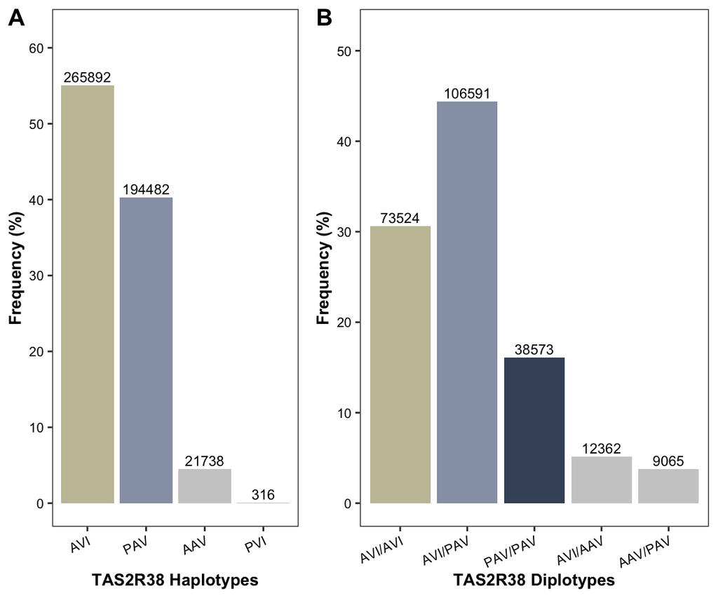

## Descriptive characteristics

Next, we summarized demographic, behavioral and health characteristics among all identified TAS2R38 diplotypes. P-values provided are for T-tests (of any differenes among CANONICAL diplotypes) and for P-trend, across additive diplotypes (0,1,2 PAV haplotypes)

Descriptive Table 1

| X | Total | AVI.AVI | AVI.PAV | PAV.PAV | P_value | P_trend |
| --- | --- | --- | --- | --- | --- | --- |
| N (%) | 218688 | 73524 (33.6%) | 106591 (48.7%) | 38573 (17.6%) | - | - |
| Age, years | 56 ± 8.1 | 56 ± 8.1 | 56 ± 8.1 | 56.1 ± 8.1 | 0.8764 | 0.5637 |
| Sex |  |  |  |  | 0.8569 | - |
| Male | 99968 (45.7%) | 33602 (45.7%) | 48685 (45.7%) | 17681 (45.8%) |  |  |
| Female | 118720 (54.3%) | 39922 (54.3%) | 57906 (54.3%) | 20892 (54.2%) |  |  |
| BMI, kg/m2 | 26.9 ± 4.4 | 26.9 ± 4.4 | 26.9 ± 4.4 | 26.9 ± 4.4 | 0.7924 | 0.9344 |
| Smoking Status |  |  |  |  | 0.6247 | - |
| Never | 122908 (56.2%) | 41432 (56.4%) | 59763 (56.1%) | 21713 (56.3%) |  |  |
| Previous | 75278 (34.4%) | 25238 (34.3%) | 36748 (34.5%) | 13292 (34.5%) |  |  |
| Current | 20502 (9.4%) | 6854 (9.3%) | 10080 (9.5%) | 3568 (9.2%) |  |  |
| Cigarettes per day (among smokers) | 17.2 ± 9.6 | 18.6 ± 11.8 | 16.4 ± 7.9 | 16.7 ± 8.9 | 0.0218 | 0.0233 |
| Physical Activity Level |  |  |  |  | 0.8472 | - |
| Low | 66229 (30.3%) | 22186 (30.2%) | 32356 (30.4%) | 11687 (30.3%) |  |  |
| Moderate | 74926 (34.3%) | 25168 (34.2%) | 36564 (34.3%) | 13194 (34.2%) |  |  |
| High | 77533 (35.5%) | 26170 (35.6%) | 37671 (35.3%) | 13692 (35.5%) |  |  |
| Physical Activity, excess MET/wk | 33.7 ± 43.2 | 33.8 ± 43.3 | 33.7 ± 43.1 | 33.7 ± 43.2 | 0.7238 | 0.5357 |
| Alcohol Frequency |  |  |  |  | 0.0073 | - |
| Daily or almost daily | 49031 (22.4%) | 16662 (22.7%) | 23930 (22.5%) | 8439 (21.9%) |  |  |
| 3-4 per week | 55123 (25.2%) | 18536 (25.2%) | 26964 (25.3%) | 9623 (24.9%) |  |  |
| 1-2 per week | 57516 (26.3%) | 19474 (26.5%) | 27777 (26.1%) | 10265 (26.6%) |  |  |
| 1-3 per month | 23442 (10.7%) | 7793 (10.6%) | 11484 (10.8%) | 4165 (10.8%) |  |  |
| Special occasions only | 20825 (9.5%) | 6875 (9.4%) | 10172 (9.5%) | 3778 (9.8%) |  |  |
| Never1 | 12751 (5.8%) | 4184 (5.7%) | 6264 (5.9%) | 2303 (6%) |  |  |
| Alcohol Frequency, 1-4 per week |  |  |  |  | 0.3533 | - |
| 1-4 per week | 112639 (51.5%) | 38010 (51.7%) | 54741 (51.4%) | 19888 (51.6%) |  |  |
| other | 106049 (48.5%) | 35514 (48.3%) | 51850 (48.6%) | 18685 (48.4%) |  |  |
| Alcohol Drinker |  |  |  |  | 0.0274 | - |
| Never2 | 6067 (2.8%) | 1923 (2.6%) | 3028 (2.8%) | 1116 (2.9%) |  |  |
| Previous1 | 6656 (3%) | 2253 (3.1%) | 3221 (3%) | 1182 (3.1%) |  |  |
| Current1 | 205937 (94.2%) | 69340 (94.3%) | 100327 (94.1%) | 36270 (94%) |  |  |
| Drinks per week | 9.1 ± 9.6 | 9.2 ± 9.6 | 9.1 ± 9.6 | 9 ± 9.6 | 0.0139 | 0.0023 |
| Education Level |  |  |  |  | 0.1111 | - |
| Level 1 | 32451 (15%) | 10799 (14.8%) | 15858 (15%) | 5794 (15.1%) |  |  |
| Level 2 | 59838 (27.6%) | 20146 (27.6%) | 29131 (27.5%) | 10561 (27.6%) |  |  |
| Level 3 | 25841 (11.9%) | 8699 (11.9%) | 12724 (12%) | 4418 (11.5%) |  |  |
| Level 4 | 10909 (5%) | 3736 (5.1%) | 5199 (4.9%) | 1974 (5.2%) |  |  |
| Level 5 | 88001 (40.5%) | 29611 (40.6%) | 42872 (40.5%) | 15518 (40.6%) |  |  |
| Income Level |  |  |  |  | 0.0258 | - |
| lt_18000 | 37006 (19.5%) | 12570 (19.6%) | 17853 (19.3%) | 6583 (19.6%) |  |  |
| from_18000_to_30999 | 46961 (24.7%) | 15892 (24.8%) | 22834 (24.6%) | 8235 (24.6%) |  |  |
| from_31000_to_51999 | 51924 (27.3%) | 17562 (27.4%) | 25317 (27.3%) | 9045 (27%) |  |  |
| from_52000_to_100000 | 42877 (22.5%) | 14128 (22.1%) | 21173 (22.8%) | 7576 (22.6%) |  |  |
| gt_100000 | 11445 (6%) | 3848 (6%) | 5533 (6%) | 2064 (6.2%) |  |  |
| SBP, mmHg (med adjusted) | 140.6 ± 20.8 | 140.5 ± 20.7 | 140.6 ± 20.8 | 140.6 ± 20.8 | 0.27 | 0.1982 |
| DBP, mmHg (med adjusted) | 82.1 ± 10.7 | 82.1 ± 10.7 | 82.1 ± 10.7 | 82.2 ± 10.6 | 0.529 | 0.3009 |
| Triglyceride, mmol/L | 1.7 ± 1 | 1.7 ± 1 | 1.7 ± 1 | 1.7 ± 1 | 0.9078 | 0.6139 |
| LDL, mmol/L | 3.6 ± 0.8 | 3.6 ± 0.8 | 3.6 ± 0.8 | 3.6 ± 0.8 | 0.7524 | 0.4676 |
| HDL, mmol/L | 1.5 ± 0.4 | 1.5 ± 0.4 | 1.5 ± 0.4 | 1.5 ± 0.4 | 0.5287 | 0.3685 |
| Coffee, cups/day | 2.1 ± 2 | 2.1 ± 2 | 2.1 ± 2 | 2 ± 2 | 5e-04 | 3e-04 |
| Tea, cups/day | 3.4 ± 2.7 | 3.4 ± 2.7 | 3.4 ± 2.7 | 3.5 ± 2.7 | 0.0044 | 7e-04 |
| Added salt |  |  |  |  | 0 | - |
| Always/Often | 33680 (15.4%) | 11809 (16.1%) | 16354 (15.3%) | 5517 (14.3%) |  |  |
| Sometimes | 60272 (27.6%) | 20681 (28.1%) | 29240 (27.4%) | 10351 (26.8%) |  |  |
| Never/Rarely | 124725 (57%) | 41029 (55.8%) | 60994 (57.2%) | 22702 (58.9%) |  |  |
| HbA1C, % | 5.3 ± 0.3 | 5.3 ± 0.3 | 5.3 ± 0.3 | 5.3 ± 0.3 | 0.2201 | 0.3259 |
| N (%)2 | 118720 | 39922 (34%) | 57906 (49%) | 20892 (18%) | - | - |
| Female: Drinks per wweek (drinkers) | 6.652 ± 7.535 | 6.685 ± 7.51 | 6.638 ± 7.541 | 6.626 ± 7.568 | 0.5423 | 0.224 |
| N (%)1 | 99968 | 33602 (34%) | 48685 (49%) | 17681 (18%) | - | - |
| Male: Drinks per wweek (drinkers) | 12.009 ± 10.882 | 12.118 ± 10.903 | 12.006 ± 10.885 | 11.81 ± 10.832 | 0.0092 | 0.0033 |
| N (%)3 | 218688 | 73524 (34%) | 106591 (49%) | 38573 (18%) | - | - |
| SBP, mmHg (med adjusted)1 | 141 ± 21 | 140 ± 21 | 141 ± 21 | 141 ± 21 | 0.27 | 0.1982 |
| DBP, mmHg (med adjusted)1 | 83 ± 11 | 83 ± 11 | 83 ± 11 | 83 ± 11 | 0.5151 | 0.2814 |
| N (%)4 | 218688 | 73524 (34%) | 106591 (49%) | 38573 (18%) | - | - |
| Glucose, mmol/L (3 digits) | 4.913 ± 0.585 | 4.916 ± 0.585 | 4.913 ± 0.586 | 4.907 ± 0.58 | 0.0539 | 0.02 |
| 0-2hr Glucose, mmol/L | 4.953 ± 0.743 | 4.965 ± 0.743 | 4.949 ± 0.748 | 4.942 ± 0.731 | 0.0172 | 0.0032 |
| Drinks per week1 | 9.101 ± 9.596 | 9.168 ± 9.606 | 9.09 ± 9.6 | 9.002 ± 9.564 | 0.0139 | 0.0023 |

Additional comparisons for Table 1 Females (top) & Males (bottom)

|  | Total | AVI/AVI | AVI/PAV | PAV/PAV | P_value | P_trend |
| --- | --- | --- | --- | --- | --- | --- |
| N (%) | 118720 | 39922 (33.6%) | 57906 (48.8%) | 20892 (17.6%) | - | - |
| ≥3 drinks/week | 48775 (41.1%) | 16412 (41.1%) | 23869 (41.2%) | 8494 (40.7%) | 0.3622 | - |
| Drinks/week | 6.65 ± 7.54 | 6.69 ± 7.51 | 6.64 ± 7.54 | 6.63 ± 7.57 | 0.5448 | 0.307 |
| Cigarettes/day | 15.84 ± 8.66 | 17.69 ± 9.45 | 15.17 ± 7.49 | 11.64 ± 6.61 | 0.3022 | 0.1226 |
| Income ≥ 50k | 25977 (21.9%) | 8591 (21.5%) | 12780 (22.1%) | 4606 (22%) | 0.1002 | - |
| coffee | 1.92 ± 1.9 | 1.95 ± 1.9 | 1.93 ± 1.9 | 1.88 ± 1.88 | 3e-04 | 1.2e-04 |
| raw_veg | 2.32 ± 1.83 | 2.32 ± 1.83 | 2.32 ± 1.83 | 2.31 ± 1.83 | 0.7726 | 0.523 |
| tea | 3.39 ± 2.65 | 3.38 ± 2.66 | 3.39 ± 2.64 | 3.43 ± 2.65 | 0.0882 | 0.041 |

|  | Total | AVI/AVI | AVI/PAV | PAV/PAV | P_value | P_trend |
| --- | --- | --- | --- | --- | --- | --- |
| N (%) | 99968 | 33602 (33.6%) | 48685 (48.7%) | 17681 (17.7%) | - | - |
| ≥3 drinks/week | 55379 (55.4%) | 18786 (55.9%) | 27025 (55.5%) | 9568 (54.1%) | 4.2e-04 | - |
| Drinks/week | 12.01 ± 10.88 | 12.12 ± 10.9 | 12.01 ± 10.89 | 11.81 ± 10.83 | 9.3e-03 | 2.6e-03 |
| Cigarettes/day | 17.26 ± 9.65 | 18.65 ± 12 | 16.45 ± 7.92 | 16.96 ± 8.99 | 0.0262 | 0.0482 |
| Income ≥ 50k | 28345 (28.4%) | 9385 (27.9%) | 13926 (28.6%) | 5034 (28.5%) | 0.1004 | - |
| coffee | 2.21 ± 2.07 | 2.22 ± 2.06 | 2.21 ± 2.08 | 2.19 ± 2.05 | 0.2967 | 0.1559 |
| raw_veg | 1.89 ± 1.74 | 1.91 ± 1.76 | 1.88 ± 1.73 | 1.86 ± 1.71 | 5.8e-03 | 1.3e-03 |
| tea | 3.46 ± 2.78 | 3.43 ± 2.78 | 3.47 ± 2.78 | 3.49 ± 2.8 | 0.0286 | 0.0102 |

#### Description of glucose levels by fasting time

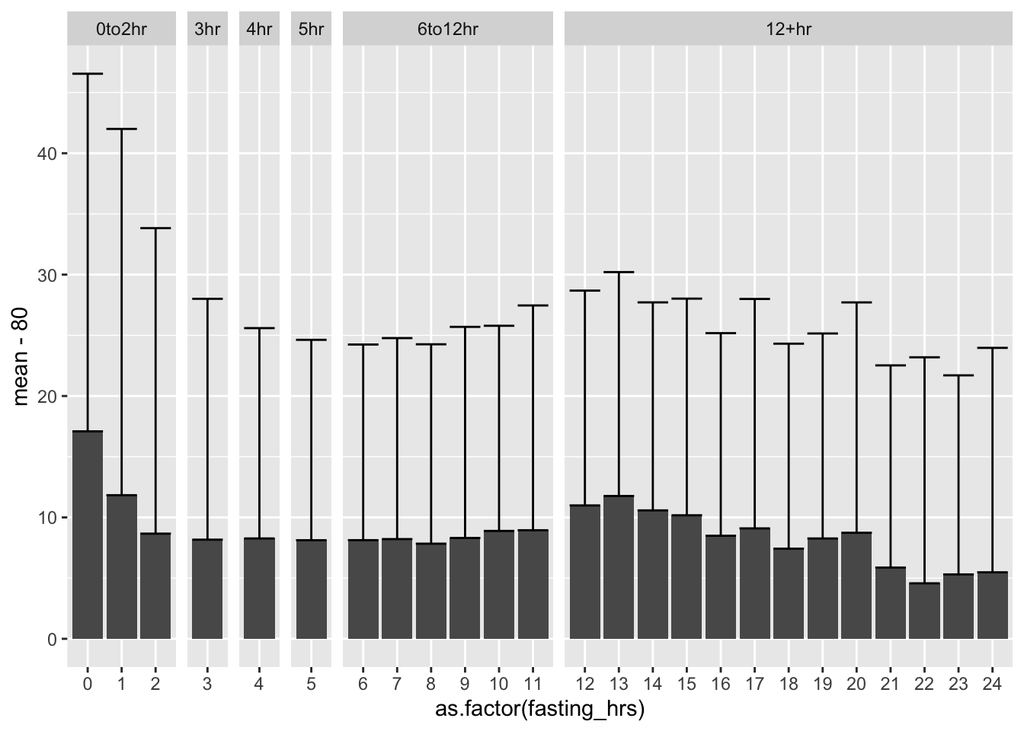

## TAS2R38 and food choices

##### Check whether diplotypes captured expected phenotypic differences in bitter-related diet trait

|  | Total | AVI/AVI | AVI/PAV | PAV/PAV | P_value | P_trend |
| --- | --- | --- | --- | --- | --- | --- |
| N (%) | 218688 | 73524 (33.6%) | 106591 (48.7%) | 38573 (17.6%) | - | - |
| Coffee, cups/day | 2.06 ± 1.98 | 2.07 ± 1.98 | 2.06 ± 1.99 | 2.02 ± 1.96 | 4.7e-04 | 1.9e-04 |
| Tea, cups/day | 3.42 ± 2.71 | 3.4 ± 2.72 | 3.43 ± 2.71 | 3.46 ± 2.72 | 4.5e-03 | 1.1e-03 |
| Raw vegetables, tbsp/day | 2.15 ± 2.03 | 2.16 ± 2.02 | 2.15 ± 2.03 | 2.13 ± 2.04 | 0.11591 | 0.042616 |
| Alcohol, drinks per week | 9.1 ± 9.6 | 9.17 ± 9.61 | 9.09 ± 9.6 | 9 ± 9.56 | 0.014157 | 2.6e-03 |
| Heavy drinker | 104154 (47.6%) | 35198 (47.9%) | 50894 (47.7%) | 18062 (46.8%) | 2.1e-03 | - |

##### Compare food choice patterns across TAS2R38 diplotypes

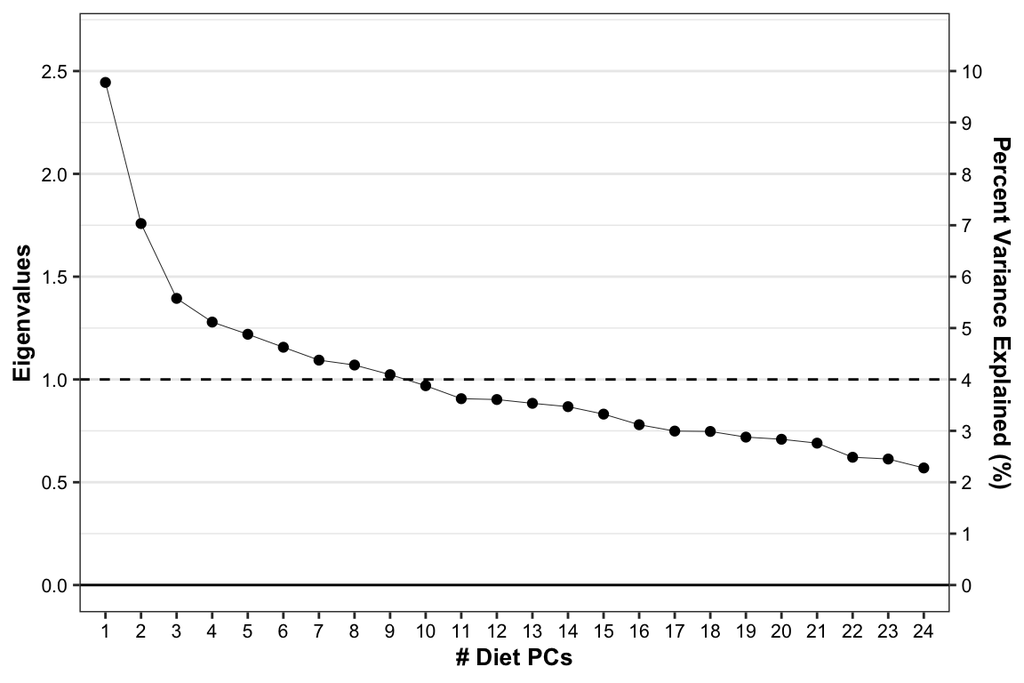

#### Examine adherence to the food choice patterns by canonical TAS2R38 diplotypes

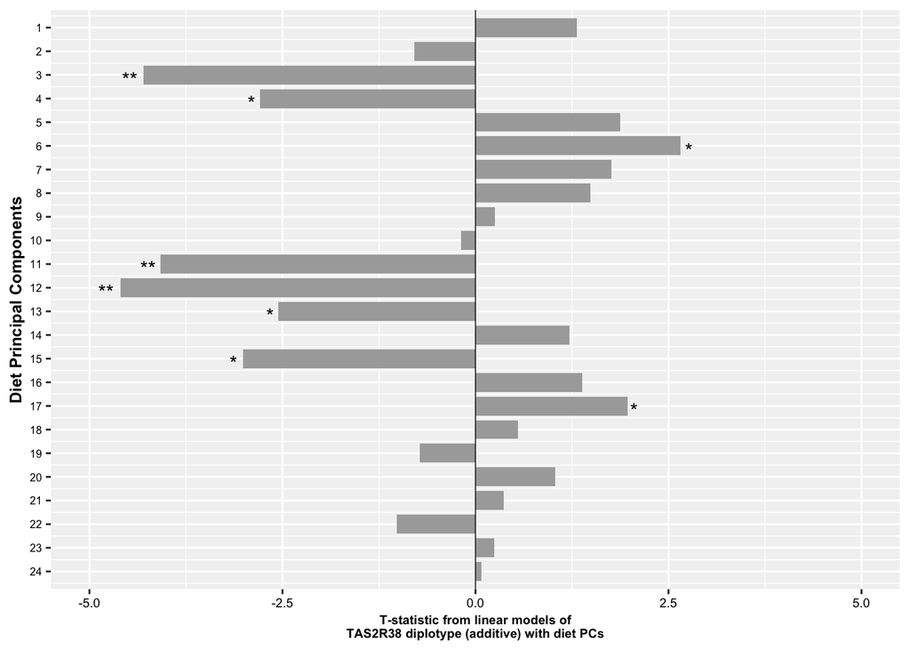

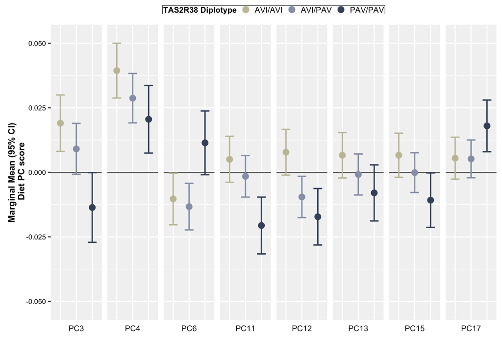

#### Run between-group comparisons for PCs with significant F-tests

| sex | taste_diplos | dietPC3 | dietPC11 | dietPC12 |
| --- | --- | --- | --- | --- |
| Female | AVI/AVI | 0.07 ± 1.14 | 0.06 ± 0.93 | -0.05 ± 0.95 |
| Female | AVI/PAV | 0.06 ± 1.14 | 0.06 ± 0.92 | -0.07 ± 0.95 |
| Female | PAV/PAV | 0.03 ± 1.13 | 0.04 ± 0.91 | -0.07 ± 0.93 |
| Male | AVI/AVI | -0.04 ± 1.19 | -0.06 ± 0.98 | 0.06 ± 0.95 |
| Male | AVI/PAV | -0.05 ± 1.19 | -0.06 ± 0.98 | 0.05 ± 0.95 |
| Male | PAV/PAV | -0.06 ± 1.19 | -0.08 ± 0.97 | 0.04 ± 0.94 |

| Outcome | Model | Exposure | N | Beta_95CI | P_t.test | P_f.test | P_trend.test |
| --- | --- | --- | --- | --- | --- | --- | --- |
| dietPC3 | dietPC3 | AVI/AVI | 73524 | - | - | 4.60e-05 | 2.25e-05 |
| dietPC3 | dietPC3 | AVI/PAV | 106591 | -0.01 (-0.021, 0.001) | 0.081 | - | - |
| dietPC3 | dietPC3 | PAV/PAV | 38573 | -0.032 (-0.047, -0.018) | 1.03e-05 | - | - |
| dietPC11 | dietPC11 | AVI/AVI | 73524 | - | - | 9.72e-05 | 6.10e-05 |
| dietPC11 | dietPC11 | AVI/PAV | 106591 | -0.006 (-0.015, 0.002) | 0.154 | - | - |
| dietPC11 | dietPC11 | PAV/PAV | 38573 | -0.025 (-0.037, -0.014) | 2.26e-05 | - | - |
| dietPC12 | dietPC12 | AVI/AVI | 73524 | - | - | 1.47e-05 | 3.43e-06 |
| dietPC12 | dietPC12 | AVI/PAV | 106591 | -0.017 (-0.026, -0.008) | 1.29e-04 | - | - |
| dietPC12 | dietPC12 | PAV/PAV | 38573 | -0.025 (-0.037, -0.014) | 1.90e-05 | - | - |

Secondary tests

*Note: I looked at interactions of taste_diplo x sex on dietPC11 and dietPC12 which seem to be sex specific. While there were no sigificant interactions its interesting that the inheritance sems to differ for males vs. females:* For males, AVI/AVI ~ AVI/PAV ≠ PAV/PAV (recessive coding, where both PAV haplotypes are needed to show an effect) * For females, AVI/AVI ≠ AVI/PAV ~ PAV/PAV (dominant coding, where one PAV haplotype is needed to show an effect)

## Primary Analysis

#### Asssociations of canonical TAS2R38 diplotype with markers of glucose homeostasis random glucose & a1c

Descriptive comparisons: Mean (SD) with sex- and age-adjusted P-values

Description of glycemic traits (,g/dL) with sex/age adjustment

| X | P_adjust | Total | AVI.AVI | AVI.PAV | PAV.PAV | P_value | P_trend |
| --- | --- | --- | --- | --- | --- | --- | --- |
| N (%) | Sex+Age | 218688 | 73524 (34%) | 106591 (49%) | 38573 (18%) | - | - |
| Glucose (md/dL) | Sex+Age | 88.52 ± 10.532 | 88.576 ± 10.544 | 88.519 ± 10.554 | 88.418 ± 10.445 | 0.056392 | 0.015619 |
| 0-2hr Glucose (mg/dL) | Sex+Age | 89.248 ± 13.394 | 89.457 ± 13.391 | 89.175 ± 13.474 | 89.046 ± 13.171 | 0.018134 | 0.004378 |
| HbA1c (%) | Sex+Age | 5.26 ± 0.268 | 5.258 ± 0.268 | 5.261 ± 0.268 | 5.26 ± 0.267 | 0.220282 | 0.344361 |

| Outcome | Model | Exposure | N | Beta_95CI | P_t.test | P_f.test | P_trend.test |
| --- | --- | --- | --- | --- | --- | --- | --- |
| Glucose (mg/dL) | Categorical.Sex+Age | AVI/AVI | 73524 | - | - | 0.056 | 0.016 |
| Glucose (mg/dL) | Categorical.Sex+Age | AVI/PAV | 106591 | -0.058 (-0.157, 0.04) | 0.243 | - | - |
| Glucose (mg/dL) | Categorical.Sex+Age | PAV/PAV | 38573 | -0.162 (-0.29, -0.033) | 0.014 | - | - |
| 0-2hr Glucose (mg/dL) | Categorical.Sex+Age | AVI/AVI | 19489 | - | - | 0.018 | 0.004 |
| 0-2hr Glucose (mg/dL) | Categorical.Sex+Age | AVI/PAV | 28110 | -0.268 (-0.51, -0.026) | 0.03 | - | - |
| 0-2hr Glucose (mg/dL) | Categorical.Sex+Age | PAV/PAV | 10053 | -0.434 (-0.753, -0.116) | 0.008 | - | - |
| HbA1c (%) | Categorical.Sex+Age | AVI/AVI | 73524 | - | - | 0.22 | 0.344 |
| HbA1c (%) | Categorical.Sex+Age | AVI/PAV | 106591 | 0.002 (0, 0.005) | 0.095 | - | - |
| HbA1c (%) | Categorical.Sex+Age | PAV/PAV | 38573 | 0.001 (-0.002, 0.004) | 0.54 | - | - |

| Outcome | Model | Exposure | N | Beta_95CI | P_t.test |
| --- | --- | --- | --- | --- | --- |
| Glucose (mg/dL) | Continuous.Sex+Age | taste_diplos.num | 218688 | -0.077 (-0.14, -0.015) | 0.016 |
| 0-2hr Glucose (mg/dL) | Continuous.Sex+Age | taste_diplos.num | 57652 | -0.226 (-0.381, -0.07) | 0.004 |
| HbA1c (%) | Continuous.Sex+Age | taste_diplos.num | 218688 | 0.001 (-0.001, 0.002) | 0.344 |

```
## Note: Bonferroni-adjusted P-value threshold for 3-related outcomes = P<0.05/3, 0.01667
```

Pairwise comparisons among all diplotypes

| outcome | model | exposure | n | beta | se | p | f | f_p | trend_p |
| --- | --- | --- | --- | --- | --- | --- | --- | --- | --- |
| glu_mgdl | AVI/AVI | AVI/AVI | 73524 | NA | NA | NA | 2.87547028664699 | 0.0563917460594098 | 0.0156191257385283 |
| glu_mgdl | AVI/AVI | AVI/PAV | 106591 | -0.0584524 | 0.0500338 | 0.242703522862451 | NA | NA |  |
| glu_mgdl | AVI/AVI | PAV/PAV | 38573 | -0.1618155 | 0.0656152 | 0.0136589973579237 | NA | NA |  |
| glu_mgdl | AVI/PAV | AVI/PAV | 106591 | NA | NA | NA | 2.87547028664663 | 0.0563917460594297 | 0.289817494486277 |
| glu_mgdl | AVI/PAV | AVI/AVI | 73524 | 0.0584524 | 0.0500338 | 0.242703522864763 | NA | NA |  |
| glu_mgdl | AVI/PAV | PAV/PAV | 38573 | -0.1033631 | 0.0620142 | 0.0955627142629472 | NA | NA |  |
| glu_mgdl | PAV/PAV | PAV/PAV | 38573 | NA | NA | NA | 2.87547028664105 | 0.0563917460597444 | 0.289817494486854 |
| glu_mgdl | PAV/PAV | AVI/AVI | 73524 | 0.1618155 | 0.0656152 | 0.0136589973580113 | NA | NA |  |
| glu_mgdl | PAV/PAV | AVI/PAV | 106591 | 0.1033631 | 0.0620142 | 0.0955627142635779 | NA | NA |  |

| outcome | model | exposure | n | beta | se | p | f | f_p | trend_p |
| --- | --- | --- | --- | --- | --- | --- | --- | --- | --- |
| glu2hr_mgdl | AVI/AVI | AVI/AVI | 19489 | NA | NA | NA | 4.01022014309082 | 0.0181344615563794 | 0.00437842034778077 |
| glu2hr_mgdl | AVI/AVI | AVI/PAV | 28110 | -0.2680478 | 0.1234567 | 0.029921000588098 | NA | NA |  |
| glu2hr_mgdl | AVI/AVI | PAV/PAV | 10053 | -0.4344199 | 0.1626384 | 0.00756294410297292 | NA | NA |  |
| glu2hr_mgdl | AVI/PAV | AVI/PAV | 28110 | NA | NA | NA | 4.01022014309331 | 0.0181344615563342 | 0.814571728999073 |
| glu2hr_mgdl | AVI/PAV | AVI/AVI | 19489 | 0.2680478 | 0.1234567 | 0.0299210005880668 | NA | NA |  |
| glu2hr_mgdl | AVI/PAV | PAV/PAV | 10053 | -0.1663721 | 0.1539184 | 0.279741148590371 | NA | NA |  |
| glu2hr_mgdl | PAV/PAV | PAV/PAV | 10053 | NA | NA | NA | 4.01022014309283 | 0.018134461556343 | 0.814571728997406 |
| glu2hr_mgdl | PAV/PAV | AVI/AVI | 19489 | 0.4344199 | 0.1626384 | 0.00756294410295081 | NA | NA |  |
| glu2hr_mgdl | PAV/PAV | AVI/PAV | 28110 | 0.1663721 | 0.1539184 | 0.279741148590726 | NA | NA |  |

| outcome | model | exposure | n | beta | se | p | f | f_p | trend_p |
| --- | --- | --- | --- | --- | --- | --- | --- | --- | --- |
| hba1c | AVI/AVI | AVI/AVI | 73524 | NA | NA | NA | 1.51285591970613 | 0.220282282282316 | 0.344361358479776 |
| hba1c | AVI/AVI | AVI/PAV | 106591 | 0.0020762 | 0.0012443 | 0.0951989102767594 | NA | NA |  |
| hba1c | AVI/AVI | PAV/PAV | 38573 | 0.0009998 | 0.0016318 | 0.540077841976346 | NA | NA |  |
| hba1c | AVI/PAV | AVI/PAV | 106591 | NA | NA | NA | 1.51285591970501 | 0.220282282282564 | 0.264837940978467 |
| hba1c | AVI/PAV | AVI/AVI | 73524 | -0.0020762 | 0.0012443 | 0.0951989102768084 | NA | NA |  |
| hba1c | AVI/PAV | PAV/PAV | 38573 | -0.0010764 | 0.0015422 | 0.485197144604844 | NA | NA |  |
| hba1c | PAV/PAV | PAV/PAV | 38573 | NA | NA | NA | 1.51285591970649 | 0.220282282282236 | 0.264837940978738 |
| hba1c | PAV/PAV | AVI/AVI | 73524 | -0.0009998 | 0.0016318 | 0.540077841978297 | NA | NA |  |
| hba1c | PAV/PAV | AVI/PAV | 106591 | 0.0010764 | 0.0015422 | 0.485197144603086 | NA | NA |  |

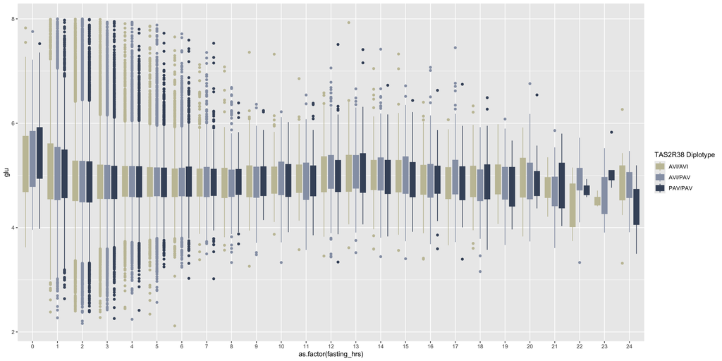

### Associations of TAS2R38 diplotype with glycemic measures

We used generalized linear models with 4 models. * Exposure: categorical diplotype (reference = AVI/AVI) * Outcomes: continunous glycemic measures * Covariates: 4 models; base, bmi, lifestyle, food choices

Associations of TAS2R38 diplotype with Random Glucose

| Outcome | Model | Exposure | N | Beta_95CI | SE | P_t.test | P_f.test | P_trend.test |
| --- | --- | --- | --- | --- | --- | --- | --- | --- |
| Glucose (md/dL) | Base | AVI/AVI | 73524 | - | - | - | 0.053007 | 0.020971 |
| Glucose (md/dL) | Base | AVI/PAV | 106591 | -0.0546 (-0.1517, 0.0424) | 0.049511 | 0.269791 | - | - |
| Glucose (md/dL) | Base | PAV/PAV | 38573 | -0.1531 (-0.2804, -0.0259) | 0.064934 | 0.018362 | - | - |
| Glucose (md/dL) | BMI | AVI/AVI | 73524 | - | - | - | 0.051927 | 0.021296 |
| Glucose (md/dL) | BMI | AVI/PAV | 106591 | -0.0561 (-0.1528, 0.0406) | 0.049339 | 0.255741 | - | - |
| Glucose (md/dL) | BMI | PAV/PAV | 38573 | -0.1515 (-0.2784, -0.0247) | 0.064708 | 0.019184 | - | - |
| Glucose (md/dL) | Lifestyle | AVI/AVI | 73524 | - | - | - | 0.051364 | 0.036071 |
| Glucose (md/dL) | Lifestyle | AVI/PAV | 106591 | -0.0506 (-0.1471, 0.046) | 0.049249 | 0.304568 | - | - |
| Glucose (md/dL) | Lifestyle | PAV/PAV | 38573 | -0.1378 (-0.2645, -0.0112) | 0.064592 | 0.032832 | - | - |
| Glucose (md/dL) | Diet.Patterns | AVI/AVI | 73524 | - | - | - | 0.051187 | 0.039954 |
| Glucose (md/dL) | Diet.Patterns | AVI/PAV | 106591 | -0.0512 (-0.1476, 0.0453) | 0.049224 | 0.298732 | - | - |
| Glucose (md/dL) | Diet.Patterns | PAV/PAV | 38573 | -0.1344 (-0.261, -0.0079) | 0.064569 | 0.037347 | - | - |

Associations of continuous TAS2R38 diplotype with Random Glucose

| Outcome | Model | Exposure | N | Beta_95CI | SE | P_t.test |
| --- | --- | --- | --- | --- | --- | --- |
| Glucose (md/dL) | Base | taste_diplos.num | 218688 | -0.0731 (-0.1351, -0.011) | 0.031648 | 0.020971 |
| Glucose (md/dL) | BMI | taste_diplos.num | 218688 | -0.0726 (-0.1344, -0.0108) | 0.031537 | 0.021296 |
| Glucose (md/dL) | Lifestyle | taste_diplos.num | 218688 | -0.066 (-0.1277, -0.0043) | 0.031481 | 0.036071 |
| Glucose (md/dL) | Diet.Patterns | taste_diplos.num | 218688 | -0.0646 (-0.1263, -0.003) | 0.031469 | 0.039954 |

Associations of TAS2R38 diplotype with 0-2hr Glucose

| Outcome | Model | Exposure | N | Beta_95CI | SE | P_t.test | P_f.test | P_trend.test |
| --- | --- | --- | --- | --- | --- | --- | --- | --- |
| 0-2hr Glucose (md/dL) | Base | AVI/AVI | 19489 | - | - | - | 0.017 | 0.003 |
| 0-2hr Glucose (md/dL) | Base | AVI/PAV | 28110 | -0.2696 (-0.51, -0.0292) | 0.123 | 0.028 | - | - |
| 0-2hr Glucose (md/dL) | Base | PAV/PAV | 10053 | -0.4595 (-0.7762, -0.1428) | 0.162 | 0.004 | - | - |
| 0-2hr Glucose (md/dL) | BMI | AVI/AVI | 19489 | - | - | - | 0.016 | 0.003 |
| 0-2hr Glucose (md/dL) | BMI | AVI/PAV | 28110 | -0.265 (-0.5037, -0.0264) | 0.122 | 0.03 | - | - |
| 0-2hr Glucose (md/dL) | BMI | PAV/PAV | 10053 | -0.4438 (-0.7581, -0.1294) | 0.16 | 0.006 | - | - |
| 0-2hr Glucose (md/dL) | Lifestyle | AVI/AVI | 19489 | - | - | - | 0.016 | 0.005 |
| 0-2hr Glucose (md/dL) | Lifestyle | AVI/PAV | 28110 | -0.2548 (-0.4932, -0.0164) | 0.122 | 0.036 | - | - |
| 0-2hr Glucose (md/dL) | Lifestyle | PAV/PAV | 10053 | -0.4293 (-0.7434, -0.1152) | 0.16 | 0.007 | - | - |
| 0-2hr Glucose (md/dL) | Diet.Patterns | AVI/AVI | 19489 | - | - | - | 0.016 | 0.004 |
| 0-2hr Glucose (md/dL) | Diet.Patterns | AVI/PAV | 28110 | -0.2585 (-0.4968, -0.0202) | 0.122 | 0.034 | - | - |
| 0-2hr Glucose (md/dL) | Diet.Patterns | PAV/PAV | 10053 | -0.4397 (-0.7536, -0.1257) | 0.16 | 0.006 | - | - |

Associations of continuous TAS2R38 diplotype with 0-2hr Glucose

| Outcome | Model | Exposure | N | Beta_95CI | SE | P_t.test |
| --- | --- | --- | --- | --- | --- | --- |
| 0-2hr Glucose (md/dL) | Base | taste_diplos.num | 57652 | -0.236 (-0.39, -0.082) | 0.079 | 0.003 |
| 0-2hr Glucose (md/dL) | BMI | taste_diplos.num | 57652 | -0.229 (-0.382, -0.076) | 0.078 | 0.003 |
| 0-2hr Glucose (md/dL) | Lifestyle | taste_diplos.num | 57652 | -0.221 (-0.374, -0.068) | 0.078 | 0.005 |
| 0-2hr Glucose (md/dL) | Diet.Patterns | taste_diplos.num | 57652 | -0.226 (-0.379, -0.073) | 0.078 | 0.004 |

Associations of TAS2R38 diplotype with HbA1c

| Outcome | Model | Exposure | N | Beta_95CI | SE | P_t.test | P_f.test | P_trend.test |
| --- | --- | --- | --- | --- | --- | --- | --- | --- |
| HbA1c | Base | AVI/AVI | 73524 | - | - | - | 0.220009 | 0.31547 |
| HbA1c | Base | AVI/PAV | 106591 | 0.0021 (-3e-04, 0.0045) | 0.001244 | 0.092589 | - | - |
| HbA1c | Base | PAV/PAV | 38573 | 0.0011 (-0.0021, 0.0043) | 0.001631 | 0.498737 | - | - |
| HbA1c | BMI | AVI/AVI | 73524 | - | - | - | 0.217001 | 0.305749 |
| HbA1c | BMI | AVI/PAV | 106591 | 0.0021 (-4e-04, 0.0045) | 0.001238 | 0.097647 | - | - |
| HbA1c | BMI | PAV/PAV | 38573 | 0.0011 (-0.002, 0.0043) | 0.001624 | 0.479238 | - | - |
| HbA1c | Lifestyle | AVI/AVI | 73524 | - | - | - | 0.212983 | 0.402257 |
| HbA1c | Lifestyle | AVI/PAV | 106591 | 0.0018 (-6e-04, 0.0043) | 0.001231 | 0.133365 | - | - |
| HbA1c | Lifestyle | PAV/PAV | 38573 | 9e-04 (-0.0023, 0.004) | 0.001614 | 0.591866 | - | - |
| HbA1c | Diet.Patterns | AVI/AVI | 73524 | - | - | - | 0.21266 | 0.49073 |
| HbA1c | Diet.Patterns | AVI/PAV | 106591 | 0.0018 (-6e-04, 0.0042) | 0.00123 | 0.150114 | - | - |
| HbA1c | Diet.Patterns | PAV/PAV | 38573 | 6e-04 (-0.0025, 0.0038) | 0.001614 | 0.702627 | - | - |

##### Plot of estimated marginal means

Associations of TAS2R38 with Glucose, Stratified by Fasting Window

| Outcome | Model | Exposure | N | Beta_95CI | P_t.test | P_f.test | P_trend.test |
| --- | --- | --- | --- | --- | --- | --- | --- |
| 0to2hr-Glucose (mg/dL) | Base | AVI/AVI | 19489 | - | - | 0.017 | 0.003 |
| 0to2hr-Glucose (mg/dL) | Base | AVI/PAV | 28110 | -0.27 (-0.51, -0.029) | 0.028 | - | - |
| 0to2hr-Glucose (mg/dL) | Base | PAV/PAV | 10053 | -0.459 (-0.776, -0.143) | 0.004 | - | - |
| 0to2hr-Glucose (mg/dL) | BMI | AVI/AVI | 19489 | - | - | 0.016 | 0.003 |
| 0to2hr-Glucose (mg/dL) | BMI | AVI/PAV | 28110 | -0.265 (-0.504, -0.026) | 0.03 | - | - |
| 0to2hr-Glucose (mg/dL) | BMI | PAV/PAV | 10053 | -0.444 (-0.758, -0.129) | 0.006 | - | - |
| 0to2hr-Glucose (mg/dL) | Lifestyle | AVI/AVI | 19489 | - | - | 0.016 | 0.005 |
| 0to2hr-Glucose (mg/dL) | Lifestyle | AVI/PAV | 28110 | -0.255 (-0.493, -0.016) | 0.036 | - | - |
| 0to2hr-Glucose (mg/dL) | Lifestyle | PAV/PAV | 10053 | -0.429 (-0.743, -0.115) | 0.007 | - | - |
| 0to2hr-Glucose (mg/dL) | Diet.Patterns | AVI/AVI | 19489 | - | - | 0.016 | 0.004 |
| 0to2hr-Glucose (mg/dL) | Diet.Patterns | AVI/PAV | 28110 | -0.258 (-0.497, -0.02) | 0.034 | - | - |
| 0to2hr-Glucose (mg/dL) | Diet.Patterns | PAV/PAV | 10053 | -0.44 (-0.754, -0.127) | 0.006 | - | - |
| 3hr-Glucose (mg/dL) | Base | AVI/AVI | 21794 | - | - | 0.712 | 0.461 |
| 3hr-Glucose (mg/dL) | Base | AVI/PAV | 31370 | -0.032 (-0.204, 0.14) | 0.719 | - | - |
| 3hr-Glucose (mg/dL) | Base | PAV/PAV | 11565 | -0.086 (-0.31, 0.138) | 0.453 | - | - |
| 3hr-Glucose (mg/dL) | BMI | AVI/AVI | 21794 | - | - | 0.71 | 0.472 |
| 3hr-Glucose (mg/dL) | BMI | AVI/PAV | 31370 | -0.032 (-0.203, 0.139) | 0.71 | - | - |
| 3hr-Glucose (mg/dL) | BMI | PAV/PAV | 11565 | -0.083 (-0.306, 0.14) | 0.468 | - | - |
| 3hr-Glucose (mg/dL) | Lifestyle | AVI/AVI | 21794 | - | - | 0.708 | 0.562 |
| 3hr-Glucose (mg/dL) | Lifestyle | AVI/PAV | 31370 | -0.029 (-0.2, 0.142) | 0.738 | - | - |
| 3hr-Glucose (mg/dL) | Lifestyle | PAV/PAV | 11565 | -0.065 (-0.288, 0.157) | 0.564 | - | - |
| 3hr-Glucose (mg/dL) | Diet.Patterns | AVI/AVI | 21794 | - | - | 0.708 | 0.556 |
| 3hr-Glucose (mg/dL) | Diet.Patterns | AVI/PAV | 31370 | -0.032 (-0.202, 0.139) | 0.717 | - | - |
| 3hr-Glucose (mg/dL) | Diet.Patterns | PAV/PAV | 11565 | -0.066 (-0.288, 0.157) | 0.563 | - | - |
| 4hr-Glucose (mg/dL) | Base | AVI/AVI | 15852 | - | - | 0.456 | 0.357 |
| 4hr-Glucose (mg/dL) | Base | AVI/PAV | 23091 | -0.045 (-0.22, 0.13) | 0.613 | - | - |
| 4hr-Glucose (mg/dL) | Base | PAV/PAV | 8392 | -0.108 (-0.336, 0.121) | 0.357 | - | - |
| 4hr-Glucose (mg/dL) | BMI | AVI/AVI | 15852 | - | - | 0.456 | 0.339 |
| 4hr-Glucose (mg/dL) | BMI | AVI/PAV | 23091 | -0.044 (-0.218, 0.131) | 0.625 | - | - |
| 4hr-Glucose (mg/dL) | BMI | PAV/PAV | 8392 | -0.113 (-0.341, 0.116) | 0.333 | - | - |
| 4hr-Glucose (mg/dL) | Lifestyle | AVI/AVI | 15852 | - | - | 0.454 | 0.36 |
| 4hr-Glucose (mg/dL) | Lifestyle | AVI/PAV | 23091 | -0.042 (-0.217, 0.132) | 0.633 | - | - |
| 4hr-Glucose (mg/dL) | Lifestyle | PAV/PAV | 8392 | -0.107 (-0.336, 0.121) | 0.356 | - | - |
| 4hr-Glucose (mg/dL) | Diet.Patterns | AVI/AVI | 15852 | - | - | 0.454 | 0.359 |
| 4hr-Glucose (mg/dL) | Diet.Patterns | AVI/PAV | 23091 | -0.041 (-0.215, 0.133) | 0.645 | - | - |
| 4hr-Glucose (mg/dL) | Diet.Patterns | PAV/PAV | 8392 | -0.108 (-0.336, 0.12) | 0.353 | - | - |
| 5hr-Glucose (mg/dL) | Base | AVI/AVI | 8740 | - | - | 0.693 | 0.947 |
| 5hr-Glucose (mg/dL) | Base | AVI/PAV | 12597 | 0.067 (-0.156, 0.29) | 0.558 | - | - |
| 5hr-Glucose (mg/dL) | Base | PAV/PAV | 4494 | -0.038 (-0.333, 0.256) | 0.799 | - | - |
| 5hr-Glucose (mg/dL) | BMI | AVI/AVI | 8740 | - | - | 0.693 | 0.944 |
| 5hr-Glucose (mg/dL) | BMI | AVI/PAV | 12597 | 0.064 (-0.159, 0.288) | 0.571 | - | - |
| 5hr-Glucose (mg/dL) | BMI | PAV/PAV | 4494 | -0.038 (-0.332, 0.257) | 0.801 | - | - |
| 5hr-Glucose (mg/dL) | Lifestyle | AVI/AVI | 8740 | - | - | 0.692 | 0.945 |
| 5hr-Glucose (mg/dL) | Lifestyle | AVI/PAV | 12597 | 0.07 (-0.152, 0.293) | 0.536 | - | - |
| 5hr-Glucose (mg/dL) | Lifestyle | PAV/PAV | 4494 | -0.016 (-0.31, 0.278) | 0.915 | - | - |
| 5hr-Glucose (mg/dL) | Diet.Patterns | AVI/AVI | 8740 | - | - | 0.692 | 0.924 |
| 5hr-Glucose (mg/dL) | Diet.Patterns | AVI/PAV | 12597 | 0.075 (-0.148, 0.298) | 0.509 | - | - |
| 5hr-Glucose (mg/dL) | Diet.Patterns | PAV/PAV | 4494 | -0.013 (-0.307, 0.281) | 0.93 | - | - |
| 6to12hr-Glucose (mg/dL) | Base | AVI/AVI | 6129 | - | - | 0.057 | 0.133 |
| 6to12hr-Glucose (mg/dL) | Base | AVI/PAV | 9211 | 0.238 (-0.028, 0.504) | 0.08 | - | - |
| 6to12hr-Glucose (mg/dL) | Base | PAV/PAV | 3332 | 0.221 (-0.126, 0.569) | 0.211 | - | - |
| 6to12hr-Glucose (mg/dL) | BMI | AVI/AVI | 6129 | - | - | 0.057 | 0.134 |
| 6to12hr-Glucose (mg/dL) | BMI | AVI/PAV | 9211 | 0.233 (-0.033, 0.499) | 0.086 | - | - |
| 6to12hr-Glucose (mg/dL) | BMI | PAV/PAV | 3332 | 0.223 (-0.124, 0.569) | 0.209 | - | - |
| 6to12hr-Glucose (mg/dL) | Lifestyle | AVI/AVI | 6129 | - | - | 0.056 | 0.103 |
| 6to12hr-Glucose (mg/dL) | Lifestyle | AVI/PAV | 9211 | 0.239 (-0.026, 0.504) | 0.078 | - | - |
| 6to12hr-Glucose (mg/dL) | Lifestyle | PAV/PAV | 3332 | 0.246 (-0.1, 0.592) | 0.164 | - | - |
| 6to12hr-Glucose (mg/dL) | Diet.Patterns | AVI/AVI | 6129 | - | - | 0.056 | 0.095 |
| 6to12hr-Glucose (mg/dL) | Diet.Patterns | AVI/PAV | 9211 | 0.232 (-0.032, 0.497) | 0.085 | - | - |
| 6to12hr-Glucose (mg/dL) | Diet.Patterns | PAV/PAV | 3332 | 0.256 (-0.09, 0.602) | 0.147 | - | - |
| 12+hr-Glucose (mg/dL) | Base | AVI/AVI | 1520 | - | - | 0.188 | 0.241 |
| 12+hr-Glucose (mg/dL) | Base | AVI/PAV | 2212 | 0.659 (0.081, 1.237) | 0.025 | - | - |
| 12+hr-Glucose (mg/dL) | Base | PAV/PAV | 737 | 0.257 (-0.523, 1.037) | 0.519 | - | - |
| 12+hr-Glucose (mg/dL) | BMI | AVI/AVI | 1520 | - | - | 0.18 | 0.181 |
| 12+hr-Glucose (mg/dL) | BMI | AVI/PAV | 2212 | 0.653 (0.082, 1.224) | 0.025 | - | - |
| 12+hr-Glucose (mg/dL) | BMI | PAV/PAV | 737 | 0.33 (-0.441, 1.1) | 0.402 | - | - |
| 12+hr-Glucose (mg/dL) | Lifestyle | AVI/AVI | 1520 | - | - | 0.174 | 0.216 |
| 12+hr-Glucose (mg/dL) | Lifestyle | AVI/PAV | 2212 | 0.609 (0.044, 1.175) | 0.035 | - | - |
| 12+hr-Glucose (mg/dL) | Lifestyle | PAV/PAV | 737 | 0.295 (-0.468, 1.059) | 0.448 | - | - |
| 12+hr-Glucose (mg/dL) | Diet.Patterns | AVI/AVI | 1520 | - | - | 0.174 | 0.199 |
| 12+hr-Glucose (mg/dL) | Diet.Patterns | AVI/PAV | 2212 | 0.624 (0.058, 1.191) | 0.031 | - | - |
| 12+hr-Glucose (mg/dL) | Diet.Patterns | PAV/PAV | 737 | 0.311 (-0.453, 1.075) | 0.425 | - | - |

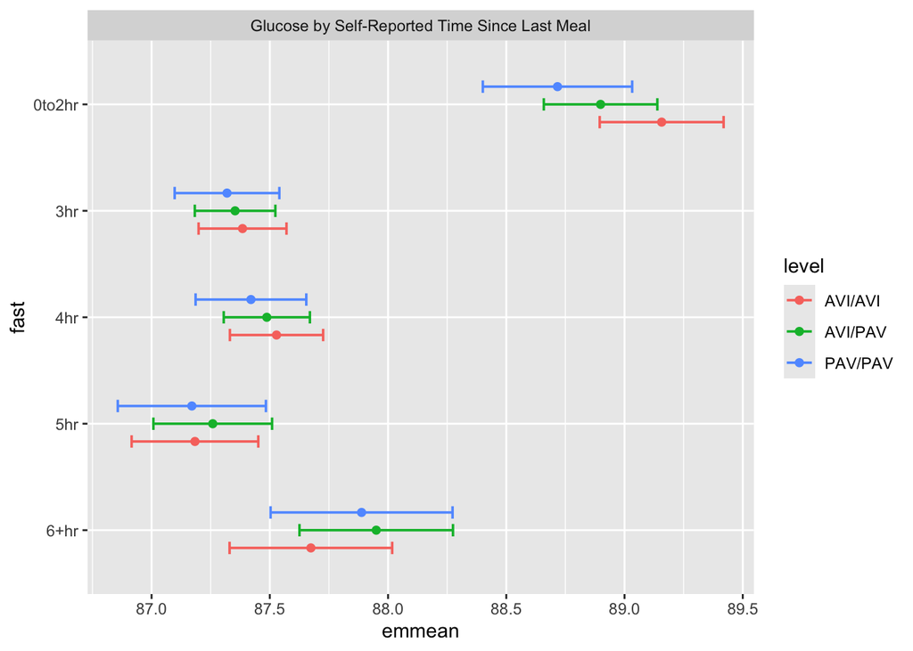

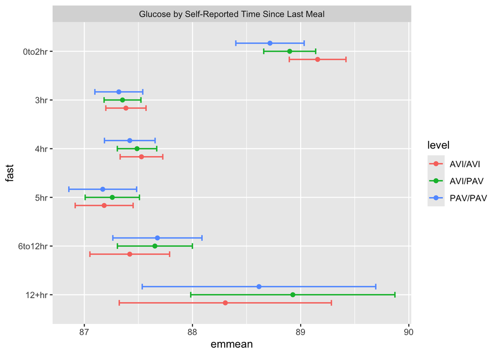

### Create combined panel plot of glycemic traits by TAS2R38 diplotype

[figure not shown]

[figure not shown]

[figure not shown]

[figure not shown]

## V2 - combining random & fasting-stratified glucose levels

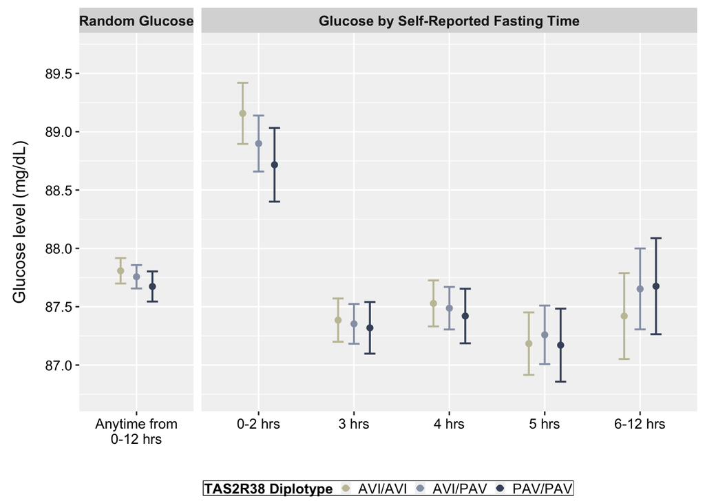

#### Additional analysis: TAS2R38 with T2D status

```
##             label      n        or    or.lci    or.uci           p        f
##            <char>  <int>     <num>     <num>     <num>       <num>    <num>
##  1:          Base  90424        NA        NA        NA          NA 126244.7
##  2:          Base 130419 0.9671300 0.9336486 1.0018122 0.062987477       NA
##  3:          Base  47263 0.9506712 0.9073883 0.9960187 0.033354036       NA
##  4:           BMI  90424        NA        NA        NA          NA 126244.7
##  5:           BMI 130419 0.9564355 0.9215403 0.9926520 0.018827520       NA
##  6:           BMI  47263 0.9441725 0.8988615 0.9917677 0.022053502       NA
##  7:     Lifestyle  90424        NA        NA        NA          NA 126244.7
##  8:     Lifestyle 130419 0.9498350 0.9148507 0.9861571 0.007187157       NA
##  9:     Lifestyle  47263 0.9355696 0.8902710 0.9831730 0.008533533       NA
## 10: Diet.Patterns  90424        NA        NA        NA          NA 126244.7
## 11: Diet.Patterns 130419 0.9517520 0.9166108 0.9882403 0.009986835       NA
## 12: Diet.Patterns  47263 0.9363727 0.8909142 0.9841507 0.009619307       NA
##            f_p
##          <num>
##  1: 0.05782794
##  2:         NA
##  3:         NA
##  4: 0.05782794
##  5:         NA
##  6:         NA
##  7: 0.05782794
##  8:         NA
##  9:         NA
## 10: 0.05782794
## 11:         NA
## 12:         NA
```

#### End of primary analysis tables & figures